# Codebook for housing

Autogenerated data summary from dataReporter

2024-03-26 13:57:10.462679

# Data report overview

The dataset examined has the following dimensions:

| Feature | Result |
| --- | --- |
| Number of observations | 18357 |
| Number of variables | 18 |

# Codebook summary table

[output not shown]

# Variable list

## household_income

| Feature | Result |
| --- | --- |
| Variable type | numeric |
| Number of missing obs. | 0 (0 %) |
| Number of unique values | 499 |
| Median | 85 |
| 1st and 3rd quartiles | 53; 129 |
| Min. and max. | 0; 1236 |

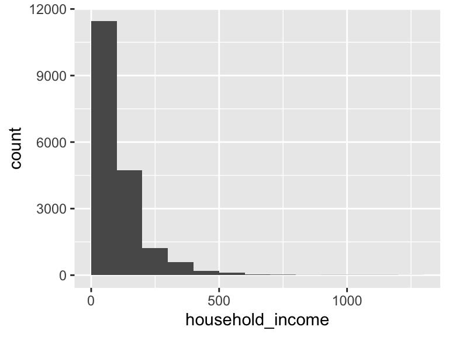

## percent_gross_rent

| Feature | Result |
| --- | --- |
| Variable type | numeric |
| Number of missing obs. | 0 (0 %) |
| Number of unique values | 635 |
| Median | 87 |
| 1st and 3rd quartiles | 56; 134 |
| Min. and max. | 2; 1400 |

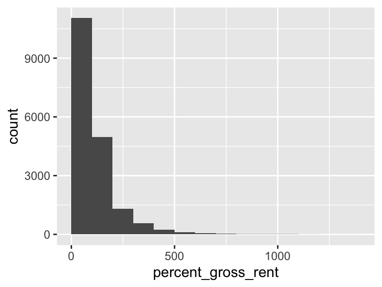

## housing_unit

| Feature | Result |
| --- | --- |
| Variable type | numeric |
| Number of missing obs. | 0 (0 %) |
| Number of unique values | 2481 |
| Median | 95000 |
| 1st and 3rd quartiles | 45000; 164650 |
| Min. and max. | -60000; 1263000 |

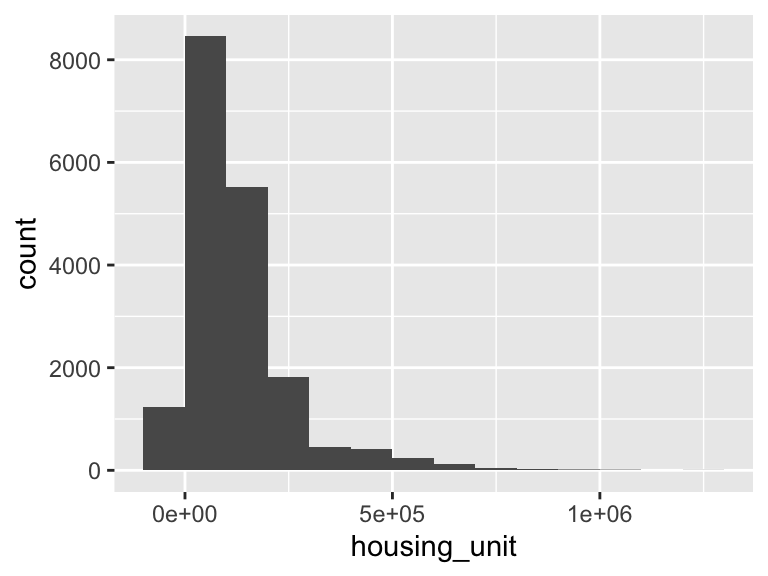

## sex

| Feature | Result |
| --- | --- |
| Variable type | numeric |
| Number of missing obs. | 0 (0 %) |
| Number of unique values | 2012 |
| Median | 21500 |
| 1st and 3rd quartiles | 0; 60300 |
| Min. and max. | -19999; 844000 |

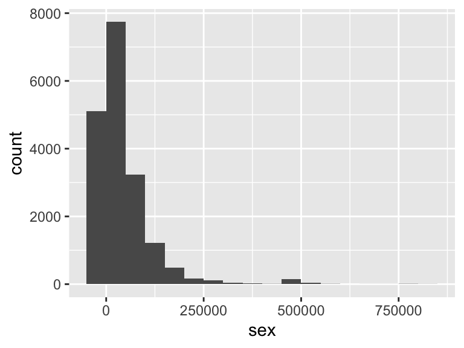

## asian

| Feature | Result |
| --- | --- |
| Variable type | numeric |
| Number of missing obs. | 0 (0 %) |
| Number of unique values | 100 |
| Median | 10 |
| 1st and 3rd quartiles | 0; 18 |
| Min. and max. | 0; 101 |

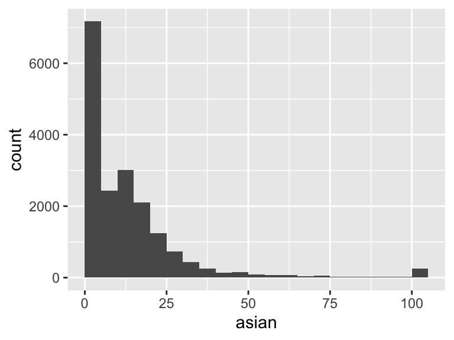

## property_taxes

| Feature | Result |
| --- | --- |
| Variable type | numeric |
| Number of missing obs. | 0 (0 %) |
| Number of unique values | 69 |
| Median | 1750 |
| 1st and 3rd quartiles | -1; 3350 |
| Min. and max. | -1; 14500 |

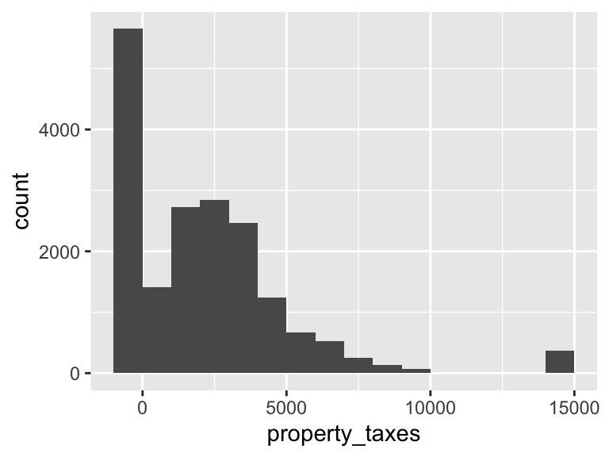

## total_income

| Feature | Result |
| --- | --- |
| Variable type | numeric |
| Number of missing obs. | 0 (0 %) |
| Number of unique values | 112 |
| Median | 0 |
| 1st and 3rd quartiles | 0; 0 |
| Min. and max. | 0; 4800 |

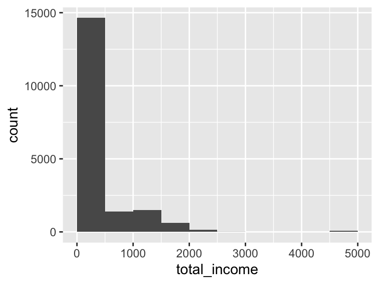

## black

| Feature | Result |
| --- | --- |
| Variable type | numeric |
| Number of missing obs. | 0 (0 %) |
| Number of unique values | 91 |
| Median | 40 |
| 1st and 3rd quartiles | 21; 60 |
| Min. and max. | 0; 93 |

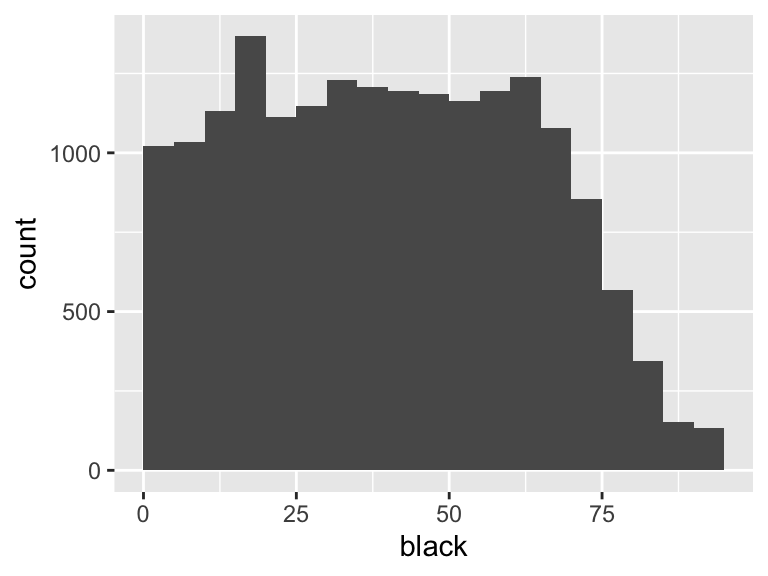

## white

| Feature | Result |
| --- | --- |
| Variable type | numeric |
| Number of missing obs. | 0 (0 %) |
| Number of unique values | 100 |
| Median | 0 |
| 1st and 3rd quartiles | 0; 0 |
| Min. and max. | 0; 101 |

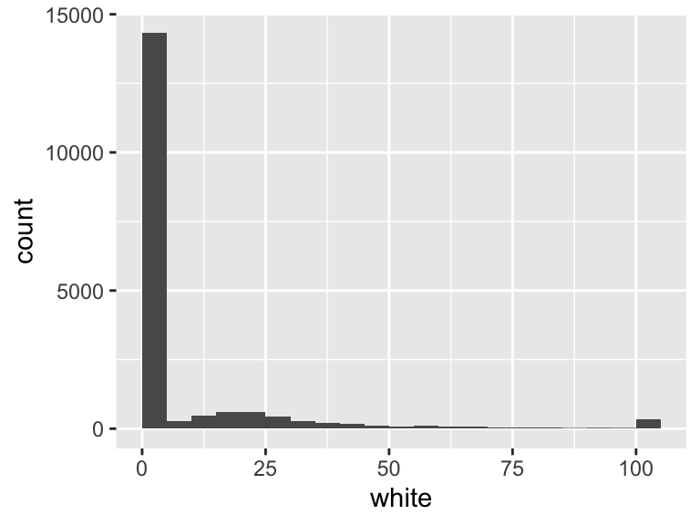

## age

| Feature | Result |
| --- | --- |
| Variable type | numeric |
| Number of missing obs. | 0 (0 %) |
| Number of unique values | 5 |
| Median | 1 |
| 1st and 3rd quartiles | 1; 2 |
| Min. and max. | 0; 4 |

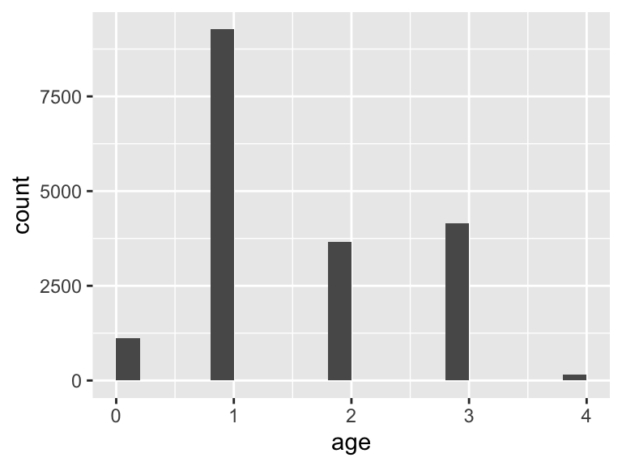

## american_indian

| Feature | Result |
| --- | --- |
| Variable type | numeric |
| Number of missing obs. | 0 (0 %) |
| Number of unique values | 2 |
| Median | 2 |
| 1st and 3rd quartiles | 1; 2 |
| Min. and max. | 1; 2 |

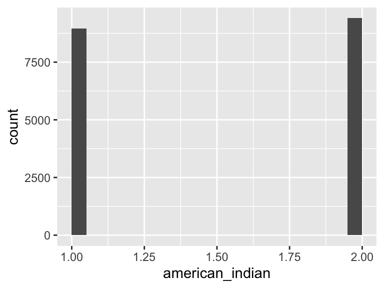

## person_weight

| Feature | Result |
| --- | --- |
| Variable type | numeric |
| Number of missing obs. | 0 (0 %) |
| Number of unique values | 2 |
| Median | 0 |
| 1st and 3rd quartiles | 0; 0 |
| Min. and max. | 0; 1 |

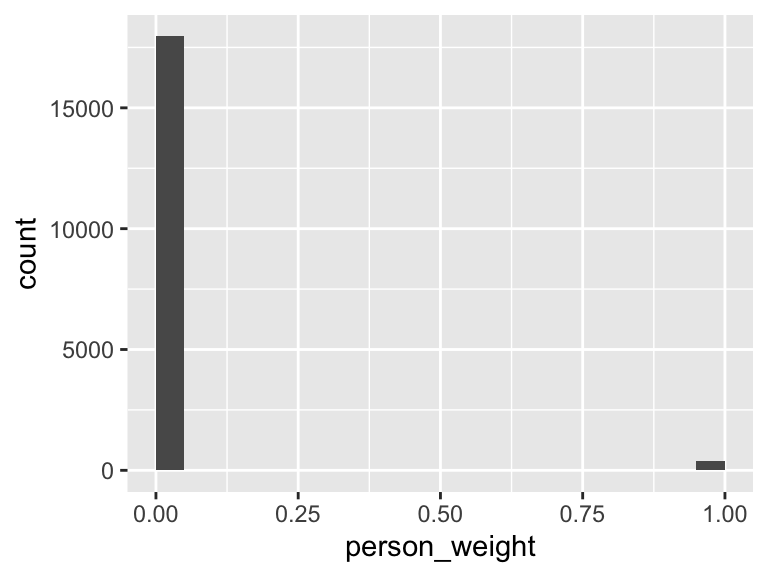

## percent_gross_own

| Feature | Result |
| --- | --- |
| Variable type | numeric |
| Number of missing obs. | 0 (0 %) |
| Number of unique values | 2 |
| Median | 0 |
| 1st and 3rd quartiles | 0; 0 |
| Min. and max. | 0; 1 |

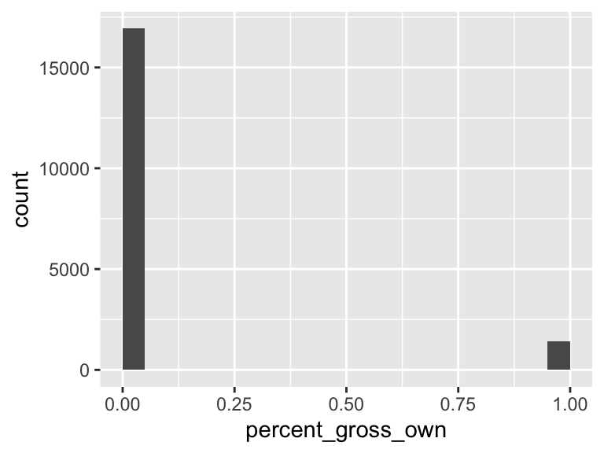

## tenure

| Feature | Result |
| --- | --- |
| Variable type | numeric |
| Number of missing obs. | 0 (0 %) |
| Number of unique values | 2 |
| Median | 1 |
| 1st and 3rd quartiles | 0; 1 |
| Min. and max. | 0; 1 |

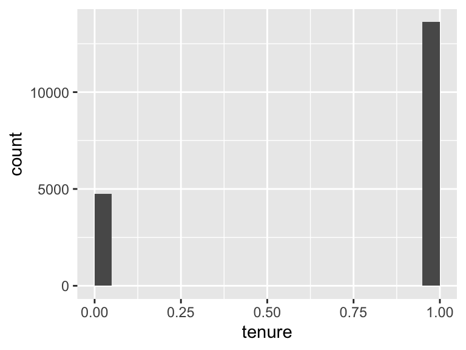

## monthly_rent

| Feature | Result |
| --- | --- |
| Variable type | numeric |
| Number of missing obs. | 0 (0 %) |
| Number of unique values | 2 |
| Median | 0 |
| 1st and 3rd quartiles | 0; 0 |
| Min. and max. | 0; 1 |

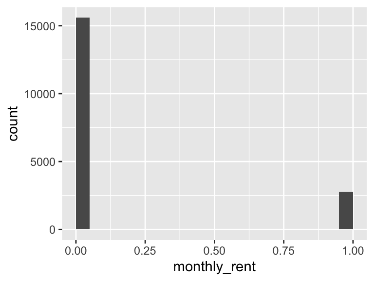

## pum_code

| Feature | Result |
| --- | --- |
| Variable type | character |
| Number of missing obs. | 0 (0 %) |
| Number of unique values | 14 |
| Mode | “01400” |

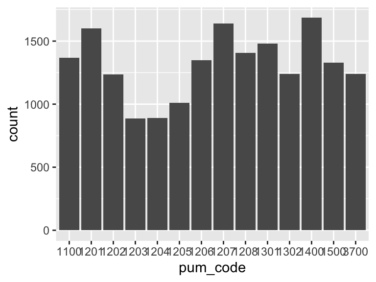

- Observed factor levels: "01100", "01201", "01202", "01203", "01204", "01205", "01206", "01207", "01208", "01301", "01302", "01400", "01500", "03700".

## county_city

- The variable only takes one (non-missing) value: "37". The variable contains 0 % missing observations.

## NA

| Feature | Result |
| --- | --- |
| Variable type | character |
| Number of missing obs. | 0 (0 %) |
| Number of unique values | 6 |
| Mode | “Wake County” |

[figure not shown]

- Observed factor levels: "Chatham & Lee Counties", "Durham County", "Johnston County", "Moore & Montgomery Counties", "Orange County", "Wake County".

Report generation information:

- Created by: Nicole Stafford (username: `nicolestafford`).
- Report creation time: Tue Mar 26 2024 13:57:11
- Report was run from directory: `/Users/nicolestafford/Documents/Duke 2023-24/Global Health 562/Final Project/562_final_project_SANS/proposal`
- dataReporter v1.0.2 [Pkg: 2021-11-11 from CRAN (R 4.3.0)]
- R version 4.3.2 (2023-10-31).
- Platform: x86_64-apple-darwin20 (64-bit)(America/New_York).
- Function call: `dataReporter::makeDataReport(data = housing, mode = c("summarize", "visualize", "check"), smartNum = FALSE, file = "codebook_housing.Rmd", replace = TRUE, checks = list(character = "showAllFactorLevels", factor = "showAllFactorLevels", labelled = "showAllFactorLevels", haven_labelled = "showAllFactorLevels", numeric = NULL, integer = NULL, logical = NULL, Date = NULL), listChecks = FALSE, maxProbVals = Inf, codebook = TRUE, reportTitle = "Codebook for housing")`